# DATA 622 - HW2 Penguin Classification

Mael Illien

2/22/2021

# LDA, QDA & Naive Bayes

## Setup

```r
library(skimr)
library(tidyverse)
library(caret) # For featureplot, classification report
library(MASS) # For LDA, QDA
library(pROC) # For AUC calculation
```

## Data Exploration

The penguin dataset is composed of 344 observations with 8 variables, 5 of which are numeric and 3 which are qualitative. The dataset is mostly complete with just a few observations with missing values that will need to be handled.

Data summary

| Name | data |
| --- | --- |
| Number of rows | 344 |
| Number of columns | 8 |
| _______________________ |  |
| Column type frequency: |  |
| factor | 3 |
| numeric | 5 |
| ________________________ |  |
| Group variables | None |

**Variable type: factor**

| skim_variable | n_missing | complete_rate | ordered | n_unique | top_counts |
| --- | --- | --- | --- | --- | --- |
| species | 0 | 1.00 | FALSE | 3 | Ade: 152, Gen: 124, Chi: 68 |
| island | 0 | 1.00 | FALSE | 3 | Bis: 168, Dre: 124, Tor: 52 |
| sex | 11 | 0.97 | FALSE | 2 | mal: 168, fem: 165 |

**Variable type: numeric**

| skim_variable | n_missing | complete_rate | mean | sd | p0 | p25 | p50 | p75 | p100 | hist |
| --- | --- | --- | --- | --- | --- | --- | --- | --- | --- | --- |
| bill_length_mm | 2 | 0.99 | 43.92 | 5.46 | 32.1 | 39.23 | 44.45 | 48.5 | 59.6 | ▃▇▇▆▁ |
| bill_depth_mm | 2 | 0.99 | 17.15 | 1.97 | 13.1 | 15.60 | 17.30 | 18.7 | 21.5 | ▅▅▇▇▂ |
| flipper_length_mm | 2 | 0.99 | 200.92 | 14.06 | 172.0 | 190.00 | 197.00 | 213.0 | 231.0 | ▂▇▃▅▂ |
| body_mass_g | 2 | 0.99 | 4201.75 | 801.95 | 2700.0 | 3550.00 | 4050.00 | 4750.0 | 6300.0 | ▃▇▆▃▂ |
| year | 0 | 1.00 | 2008.03 | 0.82 | 2007.0 | 2007.00 | 2008.00 | 2009.0 | 2009.0 | ▇▁▇▁▇ |

| species | island | bill_length_mm | bill_depth_mm | flipper_length_mm | body_mass_g | sex | year |
| --- | --- | --- | --- | --- | --- | --- | --- |
| Adelie | Torgersen | 39.1 | 18.7 | 181 | 3750 | male | 2007 |
| Adelie | Torgersen | 39.5 | 17.4 | 186 | 3800 | female | 2007 |
| Adelie | Torgersen | 40.3 | 18.0 | 195 | 3250 | female | 2007 |
| Adelie | Torgersen | NA | NA | NA | NA | NA | 2007 |
| Adelie | Torgersen | 36.7 | 19.3 | 193 | 3450 | female | 2007 |
| Adelie | Torgersen | 39.3 | 20.6 | 190 | 3650 | male | 2007 |
| Adelie | Torgersen | 38.9 | 17.8 | 181 | 3625 | female | 2007 |
| Adelie | Torgersen | 39.2 | 19.6 | 195 | 4675 | male | 2007 |
| Adelie | Torgersen | 34.1 | 18.1 | 193 | 3475 | NA | 2007 |
| Adelie | Torgersen | 42.0 | 20.2 | 190 | 4250 | NA | 2007 |

[output cut: 334 more lines]

The target variable of interest is the species of penguins, which are categorized into three groups: Adelie, Gentoo and Chinstrap penguins.

```
## [1] Adelie    Gentoo    Chinstrap
## Levels: Adelie Chinstrap Gentoo
```

### Species Distribution on Islands

From this plot, we can make a few key observations:

- Gentoo penguins are only found on Biscoe Island
- Chinstrap pengiuns only found on Dream Island
- Adelie penguins are found on all three islands
- Torgersen Island only has Adelie penguins

These island observations are valuable information in differentiating penguin species.

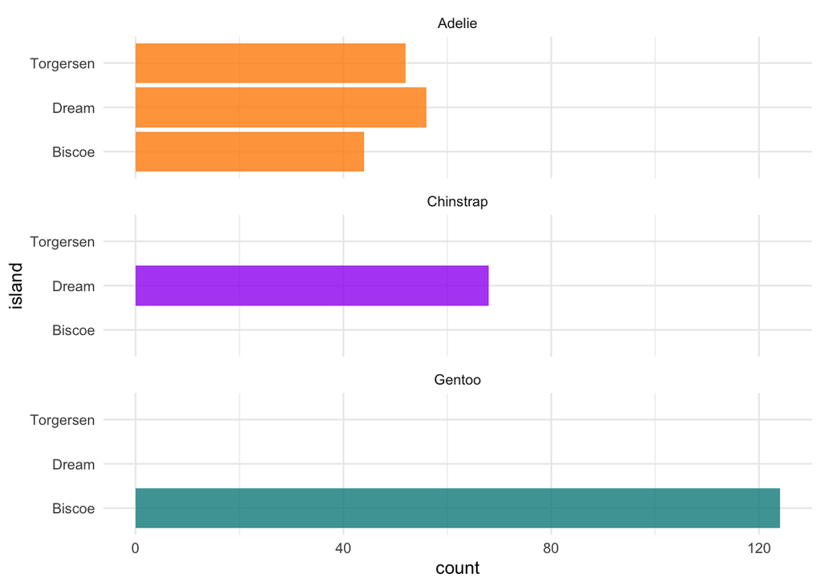

### Sex Distribution

However, the sex of the penguins does not offer much information as the proportion is about even across all species. We can also note a few missing observations labeled as NA.

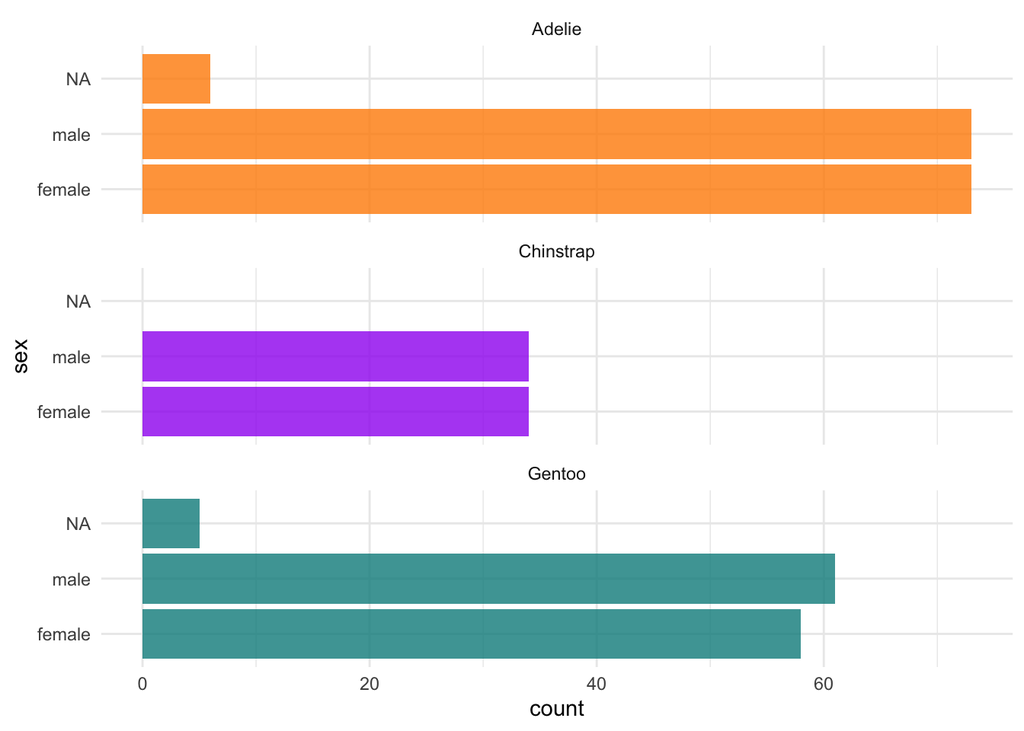

### Missing Values & Variable Selection

We noted from the data summary above that 11 observations were missing for the `sex` variable. Given that `sex` provided no useful information for differentiation, we can safely drop it from our analysis. There is also no reason to believe that the `year` the observation was taken would have any impact on the morphology of the penguins. Therefore, we also drop `year` from our predictor variables. There are also two observations which are missing body measurements altogether, so these rows will be dropped altogether.

```r
data[!complete.cases(data), ]
```

| species | island | bill_length_mm | bill_depth_mm | flipper_length_mm | body_mass_g | sex | year |
| --- | --- | --- | --- | --- | --- | --- | --- |
| Adelie | Torgersen | NA | NA | NA | NA | NA | 2007 |
| Adelie | Torgersen | 34.1 | 18.1 | 193 | 3475 | NA | 2007 |
| Adelie | Torgersen | 42.0 | 20.2 | 190 | 4250 | NA | 2007 |
| Adelie | Torgersen | 37.8 | 17.1 | 186 | 3300 | NA | 2007 |
| Adelie | Torgersen | 37.8 | 17.3 | 180 | 3700 | NA | 2007 |
| Adelie | Dream | 37.5 | 18.9 | 179 | 2975 | NA | 2007 |
| Gentoo | Biscoe | 44.5 | 14.3 | 216 | 4100 | NA | 2007 |
| Gentoo | Biscoe | 46.2 | 14.4 | 214 | 4650 | NA | 2008 |
| Gentoo | Biscoe | 47.3 | 13.8 | 216 | 4725 | NA | 2009 |
| Gentoo | Biscoe | 44.5 | 15.7 | 217 | 4875 | NA | 2009 |

[output cut: 1 more lines]

```r
data <- data[complete.cases(data), ]
data <- dplyr::select(data, -c(year, sex, island))
```

### Body Measurements

When looking at body measurements we see that Adelie and Chinstrap penguins largely overlap except for `bill_length`. This suggests that we might be able to use `bill_depth`, `body_mass` and `flipper_length` to differentiate the Gentoo penguins from the other species. However, the Adelie penguin stands out from the other others in `bill_length`

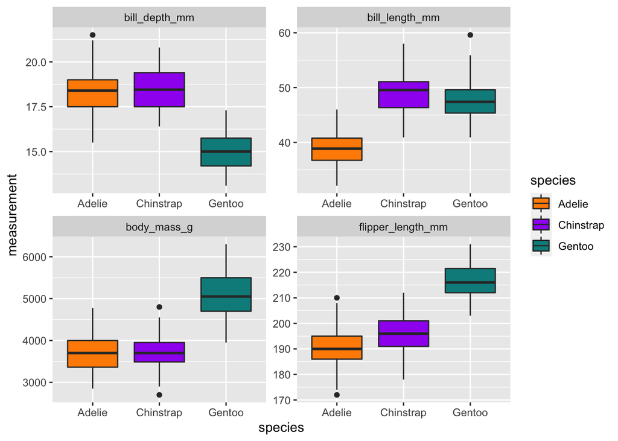

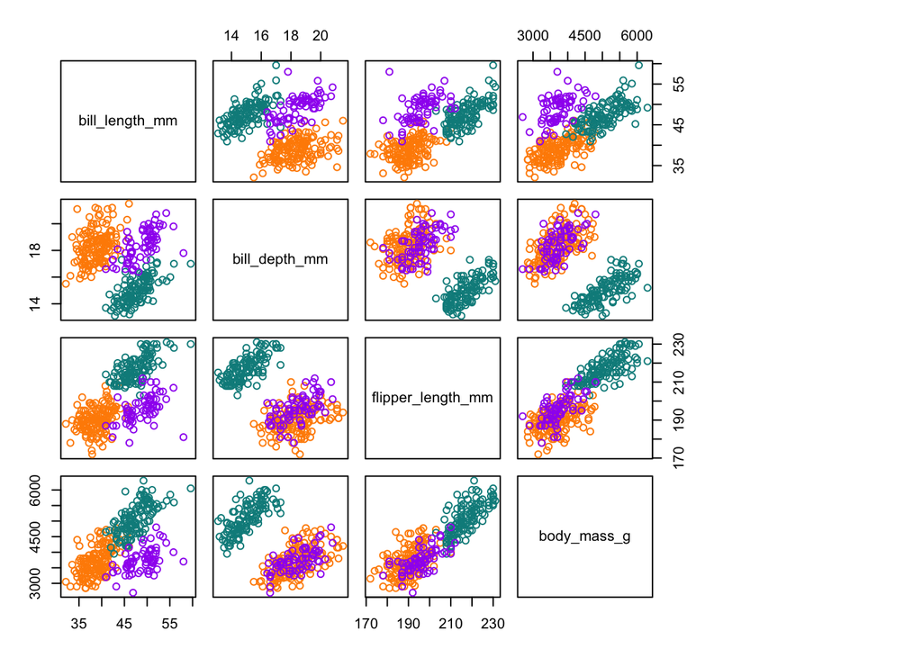

Using the featurePlot function from the caret package we can easily display data distributions such as the scatter plot matrix similat to the one above. We see on the univariate feature plots below that the data is aproximatelly normally distibuted. This is an import assumption of LDA and QDA.

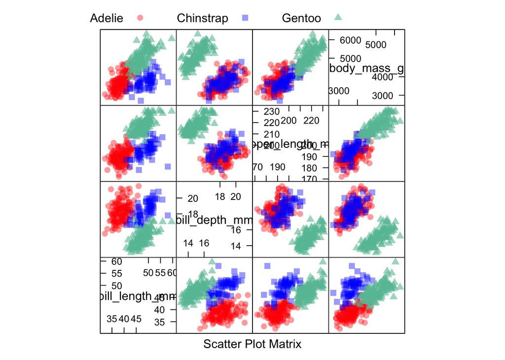

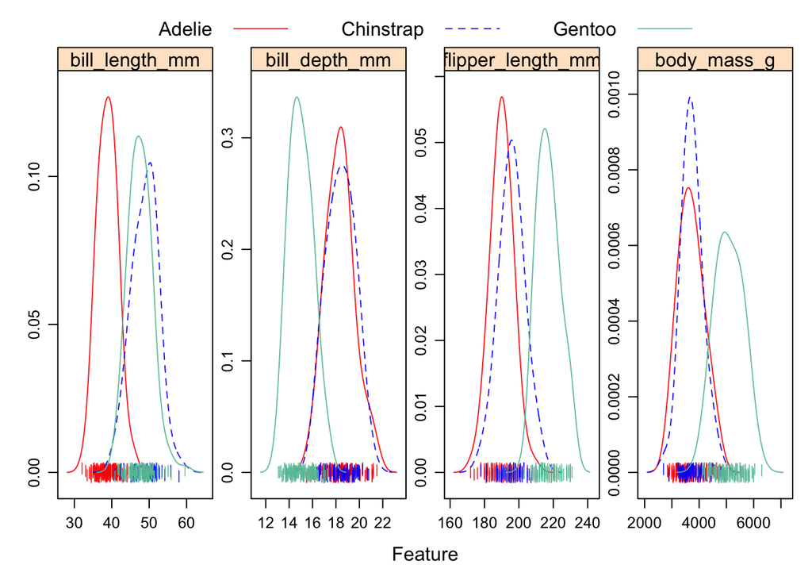

### Data Splitting

```r
set.seed(622)
trainIndex <- createDataPartition(data$species, p = .8, list = FALSE, times = 1)

training <- data[ trainIndex,]
testing  <- data[-trainIndex,]
```

## Linear Discriminant Analysis

```r
lda.fit <- lda(species ~ ., data=training)
lda.fit
```

```
## Call:
## lda(species ~ ., data = training)
##
## Prior probabilities of groups:
##    Adelie Chinstrap    Gentoo
## 0.4365672 0.2052239 0.3582090
##
## Group means:
##           bill_length_mm bill_depth_mm flipper_length_mm body_mass_g
## Adelie          38.76325      18.37521          189.4786    3688.675
## Chinstrap       48.84545      18.44182          196.0364    3757.727
## Gentoo          47.73125      15.03125          217.5208    5104.948
##
## Coefficients of linear discriminants:
##                            LD1          LD2
## bill_length_mm     0.110936069 -0.405357035
## bill_depth_mm     -1.035235061 -0.030669613
## flipper_length_mm  0.088034834  0.010337566
## body_mass_g        0.001221205  0.001762107
##
## Proportion of trace:
##    LD1    LD2
## 0.8768 0.1232
```

```r
lda.pred <- predict(lda.fit, testing)
data.frame(lda.pred)
```

|  | class | posterior.Adelie | posterior.Chinstrap | posterior.Gentoo | x.LD1 | x.LD2 |
| --- | --- | --- | --- | --- | --- | --- |
| 1 | Adelie | 9.999986e-01 | 1.408960e-06 | 1.000319e-21 | -4.6191671 | 1.491728462 |
| 2 | Adelie | 1.000000e+00 | 3.233293e-11 | 2.076032e-24 | -5.1152374 | 4.013462043 |
| 3 | Adelie | 9.999167e-01 | 8.325282e-05 | 2.824741e-15 | -2.9292390 | 1.187233832 |
| 4 | Adelie | 9.990824e-01 | 9.175843e-04 | 9.598646e-20 | -4.2200798 | 0.005139755 |
| 5 | Adelie | 9.927469e-01 | 7.253124e-03 | 8.076197e-16 | -3.1816984 | -0.071015055 |
| 6 | Adelie | 9.999962e-01 | 3.779425e-06 | 9.129521e-26 | -5.7589233 | 0.738540348 |
| 7 | Adelie | 9.999994e-01 | 5.660348e-07 | 2.243884e-17 | -3.3950863 | 2.262745415 |
| 8 | Adelie | 9.987179e-01 | 1.282116e-03 | 1.603454e-13 | -2.5070059 | 0.670990375 |
| 9 | Adelie | 9.998780e-01 | 1.219535e-04 | 1.459061e-17 | -3.5703926 | 0.807972897 |
| 10 | Adelie | 9.998563e-01 | 1.437359e-04 | 2.822679e-14 | -2.6653676 | 1.162966702 |

[output cut: 55 more lines]

```r
table(lda.pred$class, testing$species)
```

```
##
##             Adelie Chinstrap Gentoo
##   Adelie        28         1      0
##   Chinstrap      1        12      0
##   Gentoo         0         0     23
```

```r
mean(lda.pred$class==testing$species)
```

```
## [1] 0.9692308
```

## Quadratic Discriminant Analysis

```r
qda.fit <- qda(species ~ ., data=training)
qda.fit
```

```
## Call:
## qda(species ~ ., data = training)
##
## Prior probabilities of groups:
##    Adelie Chinstrap    Gentoo
## 0.4365672 0.2052239 0.3582090
##
## Group means:
##           bill_length_mm bill_depth_mm flipper_length_mm body_mass_g
## Adelie          38.76325      18.37521          189.4786    3688.675
## Chinstrap       48.84545      18.44182          196.0364    3757.727
## Gentoo          47.73125      15.03125          217.5208    5104.948
```

```r
qda.pred <- predict(qda.fit, testing)
data.frame(qda.pred)
```

|  | class | posterior.Adelie | posterior.Chinstrap | posterior.Gentoo |
| --- | --- | --- | --- | --- |
| 1 | Adelie | 9.999971e-01 | 2.914123e-06 | 1.205250e-35 |
| 2 | Adelie | 1.000000e+00 | 8.917093e-12 | 4.995113e-44 |
| 3 | Adelie | 9.990334e-01 | 9.665912e-04 | 9.021116e-25 |
| 4 | Adelie | 9.985556e-01 | 1.444414e-03 | 4.317065e-33 |
| 5 | Adelie | 9.464885e-01 | 5.351145e-02 | 1.614725e-24 |
| 6 | Adelie | 9.999978e-01 | 2.150259e-06 | 1.893397e-43 |
| 7 | Adelie | 9.999999e-01 | 6.756085e-08 | 6.767266e-32 |
| 8 | Adelie | 9.950082e-01 | 4.991767e-03 | 2.372311e-22 |
| 9 | Adelie | 9.999119e-01 | 8.811820e-05 | 1.096102e-30 |
| 10 | Adelie | 9.990533e-01 | 9.467401e-04 | 2.964100e-20 |

[output cut: 55 more lines]

```r
table(qda.pred$class, testing$species)
```

```
##
##             Adelie Chinstrap Gentoo
##   Adelie        28         0      0
##   Chinstrap      1        13      0
##   Gentoo         0         0     23
```

```r
mean(qda.pred$class==testing$species)
```

```
## [1] 0.9846154
```

## Naive Bayes

```r
library(e1071)
features <- setdiff(names(training), "species")
x <- training[,features]
y <- training$species

model.naive <- naiveBayes(x = x,
                          y = y,
                          laplace = 1)

result.naive <- predict(model.naive, testing %>% dplyr::select(-species))

# Make confusion matrix
cm.naive <- confusionMatrix(result.naive, testing$species)
cm.naive
```

```
## Confusion Matrix and Statistics
##
##            Reference
## Prediction  Adelie Chinstrap Gentoo
##   Adelie        28         1      0
##   Chinstrap      1        12      0
##   Gentoo         0         0     23
##
## Overall Statistics
##
##                Accuracy : 0.9692
##                  95% CI : (0.8932, 0.9963)
##     No Information Rate : 0.4462
##     P-Value [Acc > NIR] : < 2.2e-16
##
##                   Kappa : 0.9516
##
##  Mcnemar's Test P-Value : NA
##
## Statistics by Class:
##
##                      Class: Adelie Class: Chinstrap Class: Gentoo
## Sensitivity                 0.9655           0.9231        1.0000
## Specificity                 0.9722           0.9808        1.0000
## Pos Pred Value              0.9655           0.9231        1.0000
## Neg Pred Value              0.9722           0.9808        1.0000
## Prevalence                  0.4462           0.2000        0.3538
## Detection Rate              0.4308           0.1846        0.3538
## Detection Prevalence        0.4462           0.2000        0.3538
## Balanced Accuracy           0.9689           0.9519        1.0000
```

```r
# set up 10-fold cross validation procedure
train_control <- trainControl(
  method = "cv",
  number = 10
  )
```

```r
# features <- setdiff(names(training), "species")
# x <- training[,features]
# y <- training$species
#
# # train model
# nb.m1 <- train(
#   x = x,
#   y = y,
#   method = "nb",
#   # trControl = train_control,
#   fL=1
# )
```

```r
# search_grid <- expand.grid(
#   usekernel = c(TRUE, FALSE),
#   fL = 0:5,
#   adjust = seq(0, 5, by = 1)
# )
#
#  nb.m2 <- train(
#   x = x,
#   y = y,
#   method = "nb",
#   trControl = train_control,
#   tuneGrid = search_grid,
#   preProc = c("BoxCox", "center", "scale", "pca")
#   )
```